# Data Visualization Exercise

For this exercise, use your creativity and understanding of the different concepts of data visualization.

Create a plot (or a series of subplots) from whatever dataset you choose. As much as possible, please choose a dataset of relevance for visual storytelling. Make the plot using `python`. It doesn't matter if you choose to use `matplotlib` or `seaborn`.

For the submission:

1. Upload the code that generates the plot to your GitHub repository or to Google Classroom (whichever method you're using for submissions).
2. Upload a png file of the visualization to Google Classroom and write in the Private Comments the caption for the figure you submitted.
3. Make sure to provide the data source in the same folder.

Please make an effort to make it a good and compelling graphic. Choose your colors according to the type of data you're visualizing. Make sure to label everything and avoid clutter.

As a reference for color choices, you can go to [CARTOColors](https://carto.com/carto-colors/). Simply click on the color map of your choice and it will copy the HEX code of the color.

```python
import pandas as pd
import numpy as np
import matplotlib.pyplot as plt
import seaborn as sns

from string import ascii_letters
import warnings
warnings.filterwarnings('ignore')

%pylab inline
```

```python
plt.style.use('tableau-colorblind10') #seaborn-whitegrid #tableau-colorblind10 #fivethirtyeight

textColor = '#006680'
highlightColor = '#3b738f'
plt.rcParams['text.color'] = '#006680'
plt.rcParams['axes.labelcolor'] = '#006680'

plt.rcParams['axes.titlesize'] = 25
plt.rcParams['axes.labelsize'] = 20
plt.rcParams['xtick.labelsize'] = 14
plt.rcParams['ytick.labelsize'] = 14
```

### Data Source

- Data source: https://www.kaggle.com/unsdsn/world-happiness?select=2019.csv
- Data source: https://www.kaggle.com/tanuprabhu/population-by-country-2020

```python
# Read in data
happiness = pd.read_csv(r'C:\Users\ACER\Desktop\DLSU\World Happiness Report\happiness_2019.csv')
pop = pd.read_csv(r'C:\Users\ACER\Desktop\DLSU\World Happiness Report\population_by_country_2020.csv')
df = pd.merge(happiness,pop)
df.head(5)
```

|  | rank | country | continent | score | GDP_per_cap | social_support | healthy_life_expectancy | freedom_to_make_life_choices | generosity | perceptions_of_corruption | population | fert_rate | median_age |
| --- | --- | --- | --- | --- | --- | --- | --- | --- | --- | --- | --- | --- | --- |
| 0 | 1 | Finland | Europe | 7.769 | 1.340 | 1.587 | 0.986 | 0.596 | 0.153 | 0.393 | 5539002 | 1.5 | 43 |
| 1 | 2 | Denmark | Europe | 7.600 | 1.383 | 1.573 | 0.996 | 0.592 | 0.252 | 0.410 | 5788108 | 1.8 | 42 |
| 2 | 3 | Norway | Europe | 7.554 | 1.488 | 1.582 | 1.028 | 0.603 | 0.271 | 0.341 | 5412632 | 1.7 | 40 |
| 3 | 4 | Iceland | Europe | 7.494 | 1.380 | 1.624 | 1.026 | 0.591 | 0.354 | 0.118 | 340795 | 1.8 | 37 |
| 4 | 5 | Netherlands | Europe | 7.488 | 1.396 | 1.522 | 0.999 | 0.557 | 0.322 | 0.298 | 17127290 | 1.7 | 43 |

```python
# Perform your data wrangling and descriptive stats to help
df.shape
```

```
(147, 13)
```

```python
df.dtypes
```

```
rank                              int64
country                          object
continent                        object
score                           float64
GDP_per_cap                     float64
social_support                  float64
healthy_life_expectancy         float64
freedom_to_make_life_choices    float64
generosity                      float64
perceptions_of_corruption       float64
population                        int64
fert_rate                       float64
median_age                        int64
dtype: object
```

```python
df.describe()
```

|  | rank | score | GDP_per_cap | social_support | healthy_life_expectancy | freedom_to_make_life_choices | generosity | perceptions_of_corruption | population | fert_rate | median_age |
| --- | --- | --- | --- | --- | --- | --- | --- | --- | --- | --- | --- |
| count | 147.000000 | 147.000000 | 147.000000 | 147.000000 | 147.000000 | 147.000000 | 147.000000 | 147.000000 | 1.470000e+02 | 147.000000 | 147.000000 |
| mean | 78.251701 | 5.411993 | 0.909891 | 1.210878 | 0.734259 | 0.393592 | 0.187102 | 0.112905 | 5.092791e+07 | 2.640136 | 31.027211 |
| std | 45.521310 | 1.126534 | 0.399785 | 0.302749 | 0.233795 | 0.145884 | 0.096277 | 0.096151 | 1.680764e+08 | 1.292903 | 9.295709 |
| min | 1.000000 | 2.853000 | 0.000000 | 0.000000 | 0.105000 | 0.000000 | 0.000000 | 0.000000 | 3.407950e+05 | 1.100000 | 15.000000 |
| 25% | 39.000000 | 4.541000 | 0.594500 | 1.055500 | 0.555000 | 0.307000 | 0.110500 | 0.048500 | 5.248634e+06 | 1.700000 | 23.000000 |
| 50% | 78.000000 | 5.386000 | 0.983000 | 1.293000 | 0.798000 | 0.418000 | 0.178000 | 0.086000 | 1.179332e+07 | 2.200000 | 30.000000 |
| 75% | 117.500000 | 6.190000 | 1.229000 | 1.453000 | 0.882500 | 0.508000 | 0.252000 | 0.142500 | 3.724774e+07 | 3.350000 | 40.000000 |
| max | 156.000000 | 7.769000 | 1.684000 | 1.624000 | 1.141000 | 0.631000 | 0.566000 | 0.453000 | 1.438207e+09 | 7.000000 | 48.000000 |

```python
df.isna().sum()
```

```
rank                            0
country                         0
continent                       0
score                           0
GDP_per_cap                     0
social_support                  0
healthy_life_expectancy         0
freedom_to_make_life_choices    0
generosity                      0
perceptions_of_corruption       0
population                      0
fert_rate                       0
median_age                      0
dtype: int64
```

## How happy are our coutries?

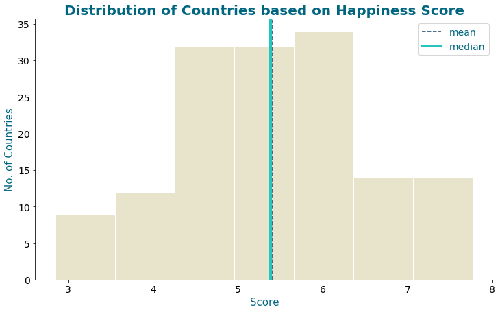

```python
# Visualize your data

ax = df['score'].hist(edgecolor='w', figsize=(12, 7), color='#E7E4CB',bins=7, width=0.7) ##b5ead7 F58C5F

ax.set_title('Distribution of Countries based on Happiness Score', color='#006680', fontsize=20, fontweight='bold')
ax.set_xlabel('Score', color='#006680', fontsize=15)
ax.set_ylabel('No. of Countries', color='#006680', fontsize=15);

ax.spines['right'].set_visible(False)
ax.spines['top'].set_visible(False)
ax.xaxis.grid(False)
ax.yaxis.grid(False)

ax.axvline(x=df['score'].mean(), color='#164066', linestyle='--', label='mean') #linestyle can -- .- -.
ax.axvline(x=df['score'].median(), color='#25C5BF', linewidth=4, label='median')
ax.legend(fontsize=14);
```

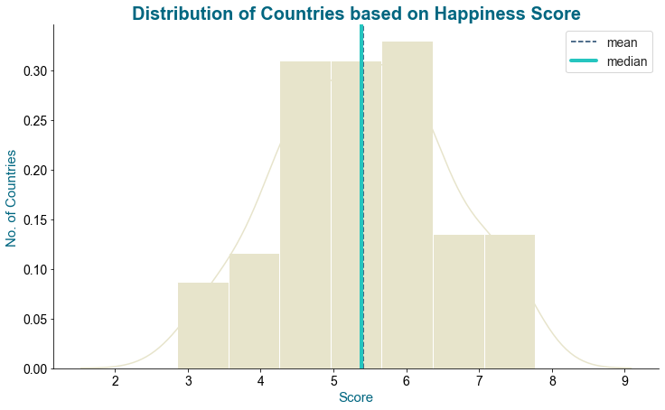

```python
import seaborn as sns, numpy as np

fig_dims = (12, 7)
fig, ax = plt.subplots(figsize=fig_dims)

sns.distplot(df['score'], color='#E7E4CB', bins=7, hist_kws={"rwidth":1,'edgecolor':'white', 'alpha':1.0})
sns.set(style="white")

ax.set_title('Distribution of Countries based on Happiness Score', color='#006680', fontweight='bold', fontsize=20,)
ax.set_xlabel('Score', color='#006680', fontsize=15)
ax.set_ylabel('No. of Countries', color='#006680', fontsize=15);

ax.spines['right'].set_visible(False)
ax.spines['top'].set_visible(False)
ax.xaxis.grid(False)

ax.axvline(x=df['score'].mean(), color='#164066', linestyle='--', label='mean') #linestyle can -- .- -.
ax.axvline(x=df['score'].median(), color='#25C5BF', linewidth=4, label='median')
ax.legend(fontsize=14);
```

Caption: The two figures above provide the distribution of countries based on the World Happiness Report score. Two different methods were used - histplot and distplot. Both figures also identify the close values of the mean and median.

## Distribution of Happiness Scores per Continent - Who is the happiest continent by average?

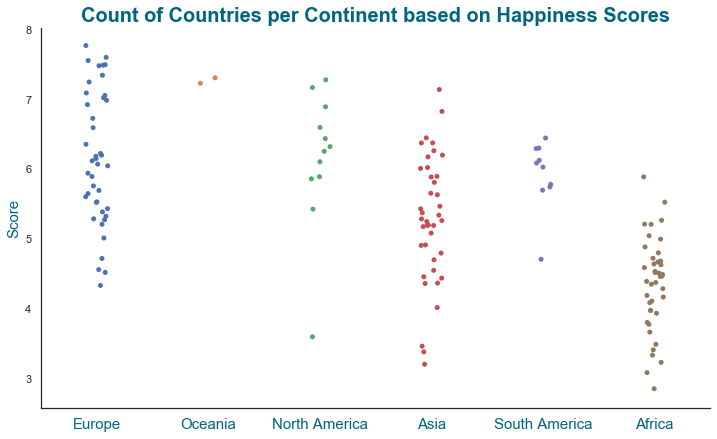

```python
fig_dims = (12, 7)
fig, ax = plt.subplots(figsize=fig_dims)

sns.stripplot(x="continent", y="score", data=df, jitter=True)
sns.set(style="white")
plt.xticks(rotation=90)

ax.set_title('Count of Countries per Continent based on Happiness Scores', color='#006680', fontweight='bold', fontsize=20,)
ax.set_ylabel('Score', color='#006680', fontsize=15);
ax.set_xlabel('');
ax.set_xticklabels(['Europe', 'Oceania', 'North America', 'Asia', 'South America', 'Africa'], rotation=0, color='#006680', fontsize=15);

ax.spines['right'].set_visible(False)
ax.spines['top'].set_visible(False)
ax.xaxis.grid(False)
```

Caption: The figure above shows observation counts on happiness scores but observations are grouped by continents.

[figure not shown]

```python
cmap = sns.diverging_palette(220, 10, as_cmap=True) #set the plot structure

fig_dims = (12, 7)
fig, ax = plt.subplots(figsize=fig_dims)
ax = df.groupby('continent')['score'].mean().sort_values().plot(kind='bar',figsize=(10,6), width=0.8, cmap=cmap)

ax.set_title('Happiness Score per Continent', color='#006680', fontweight='bold', fontsize=20,)
ax.set_ylabel('Score', color='#006680',)
ax.set_xlabel('')
ax.set_xticklabels(['Europe', 'Oceania', 'North America', 'Asia', 'South America', 'Africa'], rotation=0, color='#006680', fontsize=15);

ax.spines['right'].set_visible(False)
ax.spines['top'].set_visible(False)
ax.xaxis.grid(False)
```

```python
# Top 10 happiest countries
top10 = df.nlargest(10, 'score')
top10
```

|  | rank | country | continent | score | GDP_per_cap | social_support | healthy_life_expectancy | freedom_to_make_life_choices | generosity | perceptions_of_corruption | population | fert_rate | median_age |
| --- | --- | --- | --- | --- | --- | --- | --- | --- | --- | --- | --- | --- | --- |
| 0 | 1 | Finland | Europe | 7.769 | 1.340 | 1.587 | 0.986 | 0.596 | 0.153 | 0.393 | 5539002 | 1.5 | 43 |
| 1 | 2 | Denmark | Europe | 7.600 | 1.383 | 1.573 | 0.996 | 0.592 | 0.252 | 0.410 | 5788108 | 1.8 | 42 |
| 2 | 3 | Norway | Europe | 7.554 | 1.488 | 1.582 | 1.028 | 0.603 | 0.271 | 0.341 | 5412632 | 1.7 | 40 |
| 3 | 4 | Iceland | Europe | 7.494 | 1.380 | 1.624 | 1.026 | 0.591 | 0.354 | 0.118 | 340795 | 1.8 | 37 |
| 4 | 5 | Netherlands | Europe | 7.488 | 1.396 | 1.522 | 0.999 | 0.557 | 0.322 | 0.298 | 17127290 | 1.7 | 43 |
| 5 | 6 | Switzerland | Europe | 7.480 | 1.452 | 1.526 | 1.052 | 0.572 | 0.263 | 0.343 | 8641786 | 1.5 | 43 |
| 6 | 7 | Sweden | Europe | 7.343 | 1.387 | 1.487 | 1.009 | 0.574 | 0.267 | 0.373 | 10086531 | 1.9 | 41 |
| 7 | 8 | New Zealand | Oceania | 7.307 | 1.303 | 1.557 | 1.026 | 0.585 | 0.330 | 0.380 | 4814272 | 1.9 | 38 |
| 8 | 9 | Canada | North America | 7.278 | 1.365 | 1.505 | 1.039 | 0.584 | 0.285 | 0.308 | 37674770 | 1.5 | 41 |
| 9 | 10 | Austria | Europe | 7.246 | 1.376 | 1.475 | 1.016 | 0.532 | 0.244 | 0.226 | 8996022 | 1.5 | 43 |

## Correlation of factors against each other

How does one factor relate to another?

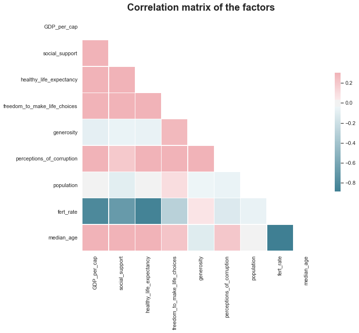

```python
df2 = df.drop(['rank', 'score'], 1) #drop as rank and score are dependent variables
sns.set(style="white")

rs = np.random.RandomState(33)
d = pd.DataFrame(data=rs.normal(size=(100, 26)),
                  columns=list(ascii_letters[26:]))

corr = df2.corr() #get corr values
mask = np.triu(np.ones_like(corr, dtype=np.bool)) #mask the upper triangle
f, ax = plt.subplots(figsize=(11, 9)) #set the plot structure
cmap = sns.diverging_palette(220, 10, as_cmap=True) #set the plot structure

sns.heatmap(corr, mask=mask, cmap=cmap, vmax=.3, center=0,
           square=True, linewidths=.5, cbar_kws={"shrink": .5}) #overall

ax.set_title('Correlation matrix of the factors', fontweight='bold',fontsize=20,)
ax.set_ylabel('')
ax.set_xlabel('')
ax.xaxis.grid(False)
```

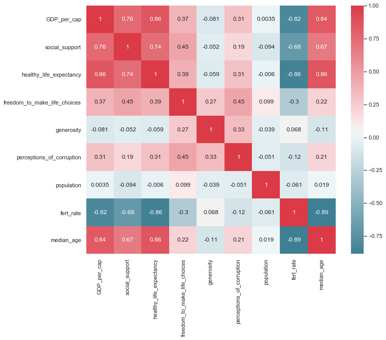

```python
plt.figure(figsize=(11,9))
sns.set(style="white")
sns.heatmap(df2.corr(), annot=True, cmap=cmap)
plt.show()
```

Caption: The two figures above show the correlation matrix of all the factors. We have dropped rank and score from the matrix as these are both dependent variables. The first matrix is only dependent on the shade of the colors whereas the second matrix also provides the actual correlation value.

```
No handles with labels found to put in legend.
```

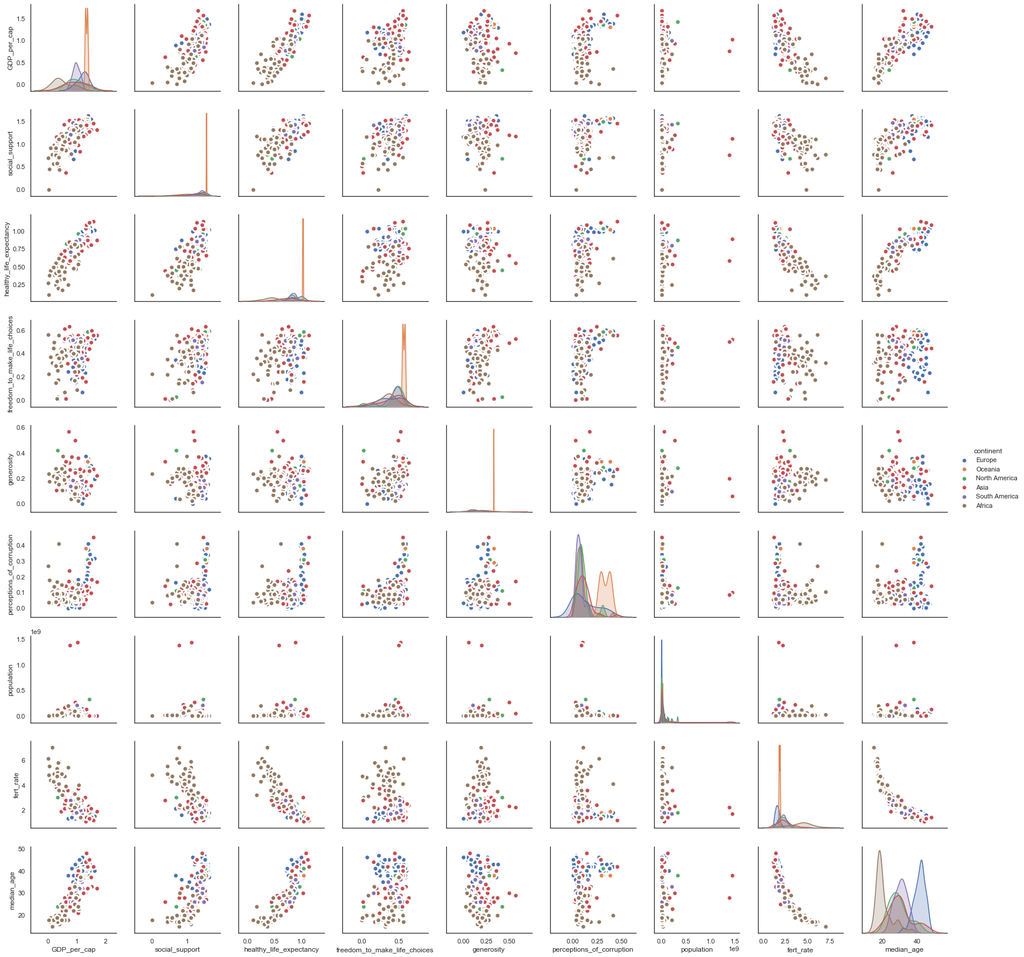

```python
fig = plt.figure(figsize=(10,8), dpi= 80)
sns.pairplot(df2, kind="scatter", hue="continent", plot_kws=dict(s=80, edgecolor="white", linewidth=2.5, cmap=cmap))

# why not showing?
ax.legend(fontsize=14)
ax.set_title('Correlation matrix of the factors', fontweight='bold',fontsize=20,)
ax.set_ylabel('')
ax.set_xlabel('')

plt.show()
```

Caption: Similar to the correlation matrix, the figure above is a pair plot which provides the relationship of each factor to another. All the correlations are visualized using multiple scatterplots.

# Let's take a closer look

## Does a better economy also mean a happier country?

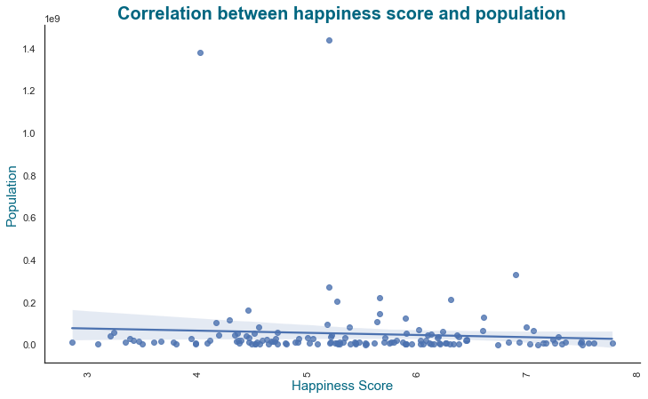

```python
fig_dims = (12, 7)
fig, ax = plt.subplots(figsize=fig_dims)

sns.regplot(x='score',y='population', data=df)
sns.set(style="white")
plt.xticks(rotation=90)

ax.set_title('Correlation between happiness score and population', color='#006680', fontweight='bold', fontsize=20,)
ax.set_ylabel('Population', color='#006680', fontsize=15);
ax.set_xlabel('Happiness Score', color='#006680', fontsize=15);

ax.spines['right'].set_visible(False)
ax.spines['top'].set_visible(False)
ax.xaxis.grid(False)
```

Caption: The figure above aims to check the correlation between population and happines score. Population difference has no impact in the score.

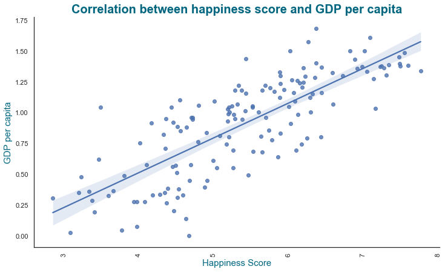

```python
fig_dims = (12, 7)
fig, ax = plt.subplots(figsize=fig_dims)

sns.regplot(x='score',y='GDP_per_cap', data=df)
sns.set(style="white")
plt.xticks(rotation=90)

ax.set_title('Correlation between happiness score and GDP per capita', color='#006680', fontweight='bold', fontsize=20,)
ax.set_ylabel('GDP per capita', color='#006680', fontsize=15);
ax.set_xlabel('Happiness Score', color='#006680', fontsize=15);

ax.spines['right'].set_visible(False)
ax.spines['top'].set_visible(False)
ax.xaxis.grid(False)
```

Caption: The figure above checks the correlation of GDP per capita with the happiness score. Countries with higher GDP per capita tend to score better in terms of World Happiness Report.

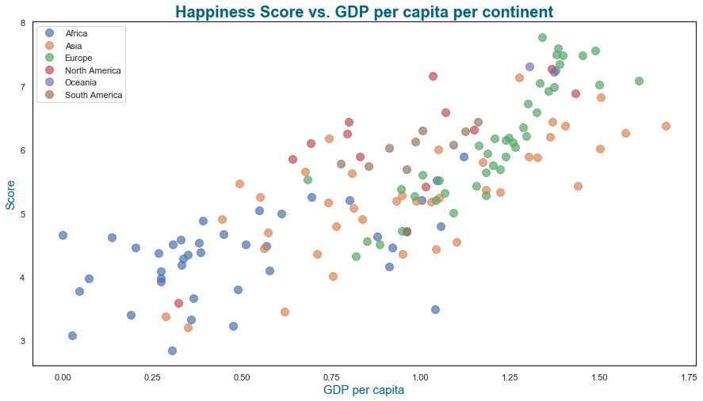

```python
fig = plt.figure(figsize=(15,8))
ax = fig.add_subplot(111)

groups = df.groupby("continent")
for name, group in groups:
    plt.plot(group["GDP_per_cap"], group["score"], marker="o", linestyle='', label=name, ms=10, alpha=0.7)

ax.set_xlabel('GDP per capita', color='#006680', fontsize=15)
ax.set_ylabel('Score', color='#006680', fontsize=15)
ax.set_title('Happiness Score vs. GDP per capita per continent', color='#006680', fontweight='bold', fontsize=20,);

plt.legend()

# Saving visualized data
fig.savefig('Happiness Score vs. GDP per capita_Rebong_Maria Concepcion.png')
```

Caption: The figure above is a scatterplot showing the correlation between the country's happines score and its GDP per capita, grouped by continent. We can observe than most of the Africa countries are on the lower left quadrant whereas most of the Europe countries are on the upper right quadrant.

## Do people trust the government more when they receive better social support?

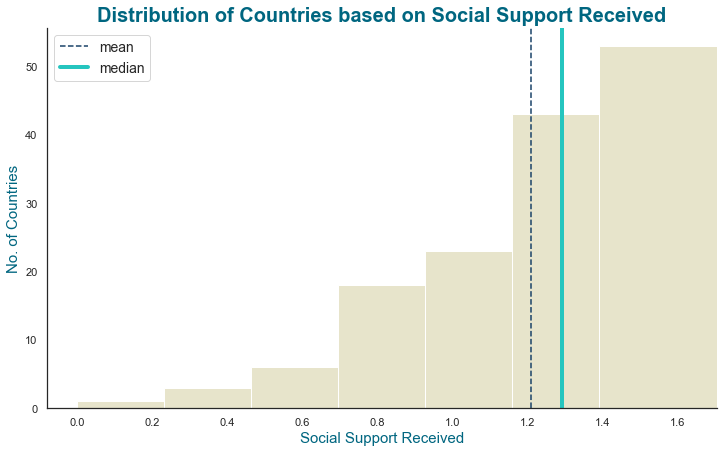

```python
ax = df['social_support'].hist(edgecolor='w', figsize=(12, 7), color='#E7E4CB',bins=7, width=0.7)

ax.set_title('Distribution of Countries based on Social Support Received', color='#006680', fontsize=20, fontweight='bold')
ax.set_xlabel('Social Support Received', color='#006680', fontsize=15)
ax.set_ylabel('No. of Countries', color='#006680', fontsize=15);

ax.spines['right'].set_visible(False)
ax.spines['top'].set_visible(False)
ax.xaxis.grid(False)
ax.yaxis.grid(False)

ax.axvline(x=df['social_support'].mean(), color='#164066', linestyle='--', label='mean')
ax.axvline(x=df['social_support'].median(), color='#25C5BF', linewidth=4, label='median')
ax.legend(fontsize=14);
```

Caption: The figure above shows that, from the 2019 retreived data, most countries receive social support.

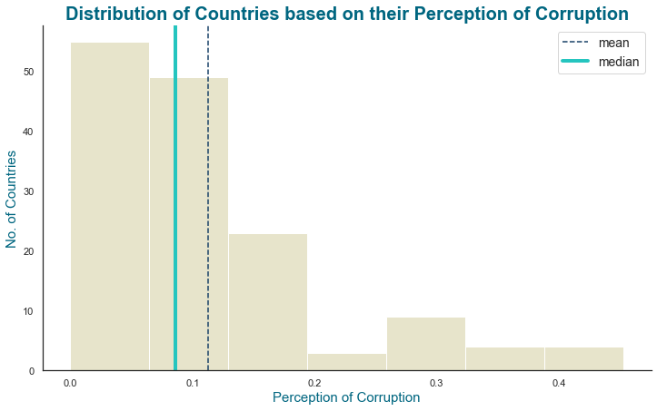

```python
ax = df['perceptions_of_corruption'].hist(edgecolor='w', figsize=(12, 7), color='#E7E4CB',bins=7)

ax.set_title('Distribution of Countries based on their Perception of Corruption', color='#006680', fontsize=20, fontweight='bold')
ax.set_xlabel('Perception of Corruption', color='#006680', fontsize=15)
ax.set_ylabel('No. of Countries', color='#006680', fontsize=15);

ax.spines['right'].set_visible(False)
ax.spines['top'].set_visible(False)
ax.xaxis.grid(False)
ax.yaxis.grid(False)

ax.axvline(x=df['perceptions_of_corruption'].mean(), color='#164066', linestyle='--', label='mean')
ax.axvline(x=df['perceptions_of_corruption'].median(), color='#25C5BF', linewidth=4, label='median')
ax.legend(fontsize=14);
```

Caption: The figure above shows that, from the 2019 retreived data, most countries also have a low perception of corruption in their government

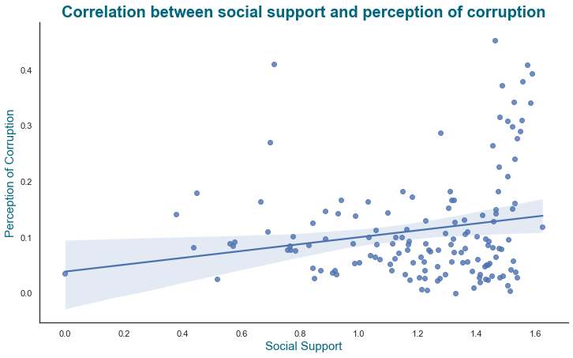

```python
fig_dims = (12, 7)
fig, ax = plt.subplots(figsize=fig_dims)

sns.regplot(x='social_support',y='perceptions_of_corruption', data=df)
sns.set(style="white")
plt.xticks(rotation=0)

ax.set_title('Correlation between social support and perception of corruption', color='#006680', fontweight='bold', fontsize=20,)
ax.set_xlabel('Social Support', color='#006680', fontsize=15);
ax.set_ylabel('Perception of Corruption', color='#006680', fontsize=15);

ax.spines['right'].set_visible(False)
ax.spines['top'].set_visible(False)
ax.xaxis.grid(False)
```

Caption: The figure above shows that there is now significant correlation between social support being received and trust in the government.

## What makes people share more?

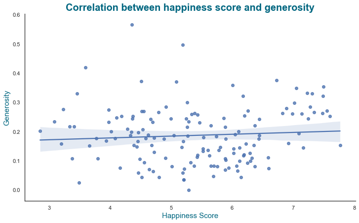

```python
fig_dims = (12, 7)
fig, ax = plt.subplots(figsize=fig_dims)

sns.regplot(x='score',y='generosity', data=df)
sns.set(style="white")
plt.xticks(rotation=0)

ax.set_title('Correlation between happiness score and generosity', color='#006680', fontweight='bold', fontsize=20,)
ax.set_xlabel('Happiness Score', color='#006680', fontsize=15);
ax.set_ylabel('Generosity', color='#006680', fontsize=15);

ax.spines['right'].set_visible(False)
ax.spines['top'].set_visible(False)
ax.xaxis.grid(False)
```

Caption: The figure above shows that happiness score does not affect the citizens' generosity

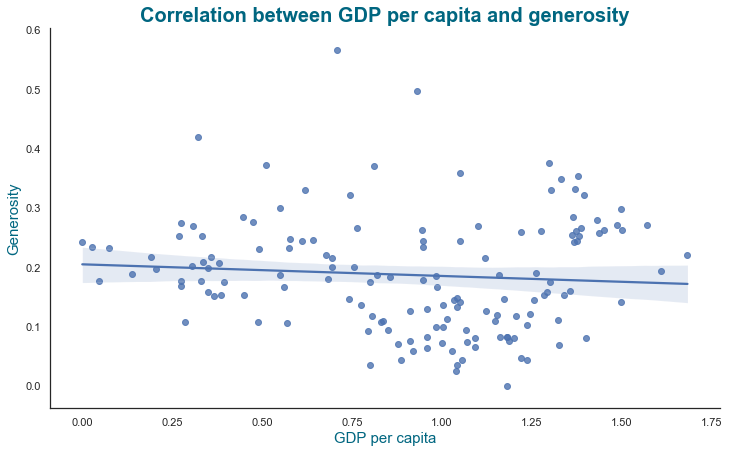

```python
fig_dims = (12, 7)
fig, ax = plt.subplots(figsize=fig_dims)

sns.regplot(x='GDP_per_cap',y='generosity', data=df)
sns.set(style="white")
plt.xticks(rotation=0)

ax.set_title('Correlation between GDP per capita and generosity', color='#006680', fontweight='bold', fontsize=20,)
ax.set_xlabel('GDP per capita', color='#006680', fontsize=15);
ax.set_ylabel('Generosity', color='#006680', fontsize=15);

ax.spines['right'].set_visible(False)
ax.spines['top'].set_visible(False)
ax.xaxis.grid(False)
```

Caption: The figure above shows that GDP per capita (economic status) does not affect the citizens' generosity

## Does freedom equate to happiness?

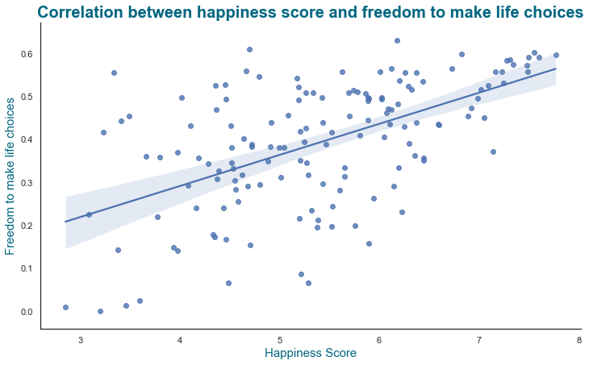

```python
fig_dims = (12, 7)
fig, ax = plt.subplots(figsize=fig_dims)

sns.regplot(x='score',y='freedom_to_make_life_choices', data=df)
sns.set(style="white")
plt.xticks(rotation=0)

ax.set_title('Correlation between happiness score and freedom to make life choices', color='#006680', fontweight='bold', fontsize=20,)
ax.set_xlabel('Happiness Score', color='#006680', fontsize=15);
ax.set_ylabel('Freedom to make life choices', color='#006680', fontsize=15);

ax.spines['right'].set_visible(False)
ax.spines['top'].set_visible(False)
ax.xaxis.grid(False)

# Saving visualized data
fig.savefig('Corr bet Happiness Score and Freedome to Life Choices_Rebong_Maria Concepcion.png')
```

Caption: In above figure, we can see that as the freedom to make life choices increase, the happiness score increases as well. However, even though there is a trend line visible, the characteristics of these features from our country observations are still relatively scattered.